```r
knitr::opts_chunk$set(warning = FALSE,
                      message = FALSE,
                      cache = TRUE,
                      global.par = TRUE)
```

```r
# Required libraries
list.of.packages <-
  c(
    'ggplot2',
    'lme4',
    'sjstats',
    'gridExtra',
    'grid',
    'gamlss',
    'epitools',
    'compute.es',
    'circular',
    'perm',
    'fitdistrplus',
    'tidyr',
    'data.table',
    'glue',
    'ggforce',
    'tidyverse',
    'here'
  )

# check to see if all the required pkgs are installed, if not, install them
new.packages <-
  list.of.packages[!(list.of.packages %in% installed.packages()[, "Package"])]
if (length(new.packages))
  install.packages(new.packages)

# load required libraries
lapply(list.of.packages, require, character.only = TRUE)
```

[output not shown]

```r
#Plot theme used for majority of the paper plots

theme_great_plot <- function (bs = 12) {
  theme_bw(base_size = bs) %+replace%
    theme(
      axis.text = element_text(size = rel(0.8)),
      plot.title = element_text(
        hjust = 0.5,
        vjust = 1,
        size = rel(1.1),
        colour = "dodgerblue4"
      ),
      axis.title.x = element_text(colour = "dodgerblue4"),
      axis.title.y = element_text(colour = "dodgerblue4", angle = 90),
      axis.text.x = element_text(face = "bold"),
      axis.text.y = element_text(face = "bold")
    )
}
```

## Archaeology/Experimental data comparisons

### Section 2.1 experiment and archaeology core/flake size plots and comparisons

Add experiment lithic measurement data from setup

```r
lithic_data <-
  read_csv(paste0(here::here(), "/data/lithic_data.csv"),
           na = c("NA", '<NA>'))
str(lithic_data)
```

```
## Classes 'tbl_df', 'tbl' and 'data.frame':    409 obs. of  7 variables:
##  $ ID        : int  1 2 3 5 6 7 8 9 10 11 ...
##  $ Series_ID : chr  "1_0001" "1_0002" "1_0003" "1_0005" ...
##  $ Class     : chr  "freehand core" "freehand core" "freehand core" "freehand core" ...
##  $ Weight    : num  14.6 12.1 16.5 16.8 10.2 19.2 7.5 14.6 8.2 11.1 ...
##  $ Max.length: num  31.9 35.3 33 33 26.6 ...
##  $ Max.width : num  25.4 32.4 27.8 31.1 26.5 ...
##  $ Max.thick : num  22.6 11.7 22.9 16.1 15.2 ...
##  - attr(*, "spec")=List of 2
##   ..$ cols   :List of 7
##   .. ..$ ID        : list()
##   .. .. ..- attr(*, "class")= chr  "collector_integer" "collector"
##   .. ..$ Series_ID : list()
##   .. .. ..- attr(*, "class")= chr  "collector_character" "collector"
##   .. ..$ Class     : list()
##   .. .. ..- attr(*, "class")= chr  "collector_character" "collector"
##   .. ..$ Weight    : list()
##   .. .. ..- attr(*, "class")= chr  "collector_double" "collector"
##   .. ..$ Max.length: list()
##   .. .. ..- attr(*, "class")= chr  "collector_double" "collector"
##   .. ..$ Max.width : list()
##   .. .. ..- attr(*, "class")= chr  "collector_double" "collector"
##   .. ..$ Max.thick : list()
##   .. .. ..- attr(*, "class")= chr  "collector_double" "collector"
##   ..$ default: list()
##   .. ..- attr(*, "class")= chr  "collector_guess" "collector"
##   ..- attr(*, "class")= chr "col_spec"
```

```r
#add event variable with which to merge and distinguish experiment and archaeology data sets

lithic_data$event <- "experiment"

#Create core/flake column

lithic_data <-
lithic_data %>%
  mutate(type = if_else(Class %in% c("freehand core",
                                     "bipolar core"),
                         'core',
                         'flake'))

### add archaeological lithic data

arc_data <- read_csv(paste0(here::here(), "/data/arc_data.csv"))

str(arc_data)
```

```
## Classes 'tbl_df', 'tbl' and 'data.frame':    938 obs. of  7 variables:
##  $ site         : chr  "sehonghong" "sehonghong" "sehonghong" "sehonghong" ...
##  $ type         : chr  "core" "core" "core" "core" ...
##  $ bipolar      : chr  "bipolar" "bipolar" "bipolar" "bipolar" ...
##  $ max_length   : num  10.9 18.3 24.5 22.6 15.8 ...
##  $ max_width    : num  5.3 24.98 21.84 13.06 6.72 ...
##  $ max_thickness: num  4 28.43 8.13 18.65 4.85 ...
##  $ mass         : num  0.38 11.4 5.17 6.73 0.43 3.98 0.1 0.23 0.48 0.14 ...
##  - attr(*, "spec")=List of 2
##   ..$ cols   :List of 7
##   .. ..$ site         : list()
##   .. .. ..- attr(*, "class")= chr  "collector_character" "collector"
##   .. ..$ type         : list()
##   .. .. ..- attr(*, "class")= chr  "collector_character" "collector"
##   .. ..$ bipolar      : list()
##   .. .. ..- attr(*, "class")= chr  "collector_character" "collector"
##   .. ..$ max_length   : list()
##   .. .. ..- attr(*, "class")= chr  "collector_double" "collector"
##   .. ..$ max_width    : list()
##   .. .. ..- attr(*, "class")= chr  "collector_double" "collector"
##   .. ..$ max_thickness: list()
##   .. .. ..- attr(*, "class")= chr  "collector_double" "collector"
##   .. ..$ mass         : list()
##   .. .. ..- attr(*, "class")= chr  "collector_double" "collector"
##   ..$ default: list()
##   .. ..- attr(*, "class")= chr  "collector_guess" "collector"
##   ..- attr(*, "class")= chr "col_spec"
```

```r
#rename archaeological size variables to match experimental size data

setnames(
  arc_data,
  old = c('site', 'max_length', 'max_width', 'max_thickness', 'mass'),
  new = c('event', 'Max.length', 'Max.width', 'Max.thick', 'Weight')
)

#merge experimental lithic and archaeological lithic size data sets, delete unused vars

combined_arc_exp_data <-
  arc_data %>%
  full_join(lithic_data, by = c(
    "event",
    "type",
    'Max.length',
    'Max.width',
    'Max.thick',
    'Weight'
  )) %>%
  select(-bipolar)

combined_arc_exp_data  <-
  combined_arc_exp_data %>%
  mutate(event = factor(event,
                        levels = c("klipfonteinrand",
                                   "sehonghong" ,
                                   "experiment" )))

##Core size

#Subset cores data

lithic_data_cores <-
  combined_arc_exp_data %>%
  filter(type == "core") %>%
  mutate(bipolar = Class)

#recode variable level names

lithic_data_cores <-
  lithic_data_cores %>%
  mutate(bipolar = str_trim(str_replace_all(bipolar, "core", "")))

#plot core sizes by 'event', generate ANOVA test results and cohen's F effect size statistic
createComparisonPlot <- function(df, y_var, y_label, graph_title) {

  comparison_plot <- ggplot(df,
                            aes_string(x = "bipolar",
                                       y = y_var,
                                       fill = "event")) +
    geom_boxplot(outlier.size = 0,
                 outlier.colour = 'white') +
    scale_fill_grey(start = 0,
                    end = .9) +
    theme_great_plot()

  comparison_plot <- comparison_plot +
    geom_point(
      aes_string(y = y_var,
                 group = 'event'),
      position = position_dodge(width = 0.75),
      na.rm = TRUE
    ) +
    labs(title = graph_title,
         x = "Technology",
         y = y_label) +
    scale_x_discrete(labels = c("Bipolar", "Freehand"))

  return(comparison_plot)
}

createComparisonPlot_flakes <-
  function(df, y_var, y_label, graph_title) {
    comparison_plot <- ggplot(df,
                              aes_string(x = "event",
                                         y = y_var,
                                         fill = "event")) +
      geom_boxplot(outlier.size = 0,
                   outlier.colour = 'white') +
      scale_fill_grey(start = 0,
                      end = .9) +
      theme_great_plot()

    comparison_plot <- comparison_plot +
      geom_point(
        aes_string(y = y_var,
                   group = 'event'),
        position = position_dodge(width = 0.75),
        na.rm = TRUE
      ) +
      labs(title = graph_title,
           x = "Assemblage",
           y = y_label) +
      scale_x_discrete(labels = c("Klipfonteinrand",
                                  "Sehonghong",
                                  "Experiment")) +
      guides(fill = FALSE)

    return(comparison_plot)
  }

createAnova <- function(df, y_var) {
  frm <- as.formula(sprintf("%s~%s", y_var, "event"))
  compare_aov <- aov(frm, data = df)
  return(compare_aov)
}

fullTests <- function(df, y_var, y_label, graph_title) {
  compare_aov = createAnova(df, y_var)
  summary_aov <- summary(compare_aov)
  cohens_f <- cohens_f(compare_aov)
  return(list(
    summary_aov = summary(compare_aov),
    cohens_f = cohens_f(compare_aov),
    plot = createComparisonPlot(df, y_var, y_label, graph_title)))
}

fullTests_flakes <- function(df, y_var, y_label, graph_title) {
  compare_aov = createAnova(df, y_var)
  summary_aov <- summary(compare_aov)
  cohens_f <- cohens_f(compare_aov)
  return(list(
    summary_aov = summary_aov,
    cohens_f = cohens_f,
    plot = createComparisonPlot_flakes(df, y_var, y_label, graph_title)))
}

#common plot one legend
grid_arrange_shared_legend <- function(...) {
  plots <- list(...)
  g <-
    ggplotGrob(plots[[1]] + theme(legend.position = "bottom"))$grobs
  legend <-
    g[[which(sapply(g, function(x)
      x$name) == "guide-box")]]
  lheight <- sum(legend$height)
  grid.arrange(
    do.call(arrangeGrob, lapply(plots, function(x)
      x + theme(legend.position = "none"))),
    legend,
    ncol = 1,
    heights = unit.c(unit(1, "npc") - lheight, lheight)
  )
}
```

Plot core size by ‘event’, generate ANOVA test results and cohen’s F effect size statistic

Table 1

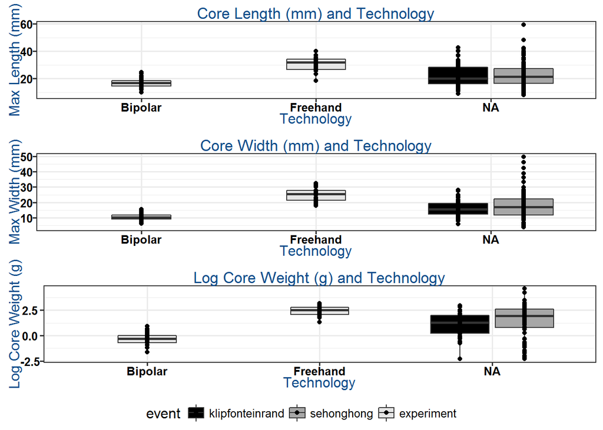

```r
core_plot_length <-
  fullTests(
    lithic_data_cores,
    y_var = 'Max.length',
    y_label = "Max Length (mm)",
    graph_title = "Core Length (mm) and Technology"
  )

core_plot_width <-
  fullTests(
    lithic_data_cores,
    y_var = 'Max.width',
    y_label = "Max Width (mm)",
    graph_title = "Core Width (mm) and Technology"
  )

core_plot_weight <-
  fullTests(
    lithic_data_cores,
    y_var = 'log(Weight)',
    y_label = "Log Core Weight (g)",
    graph_title = "Log Core Weight (g) and Technology"
  )

#Figure 7 combined plot
grid_arrange_shared_legend(core_plot_length$plot,
                           core_plot_width$plot,
                           core_plot_weight$plot)
```

Flake size

Subset flakes

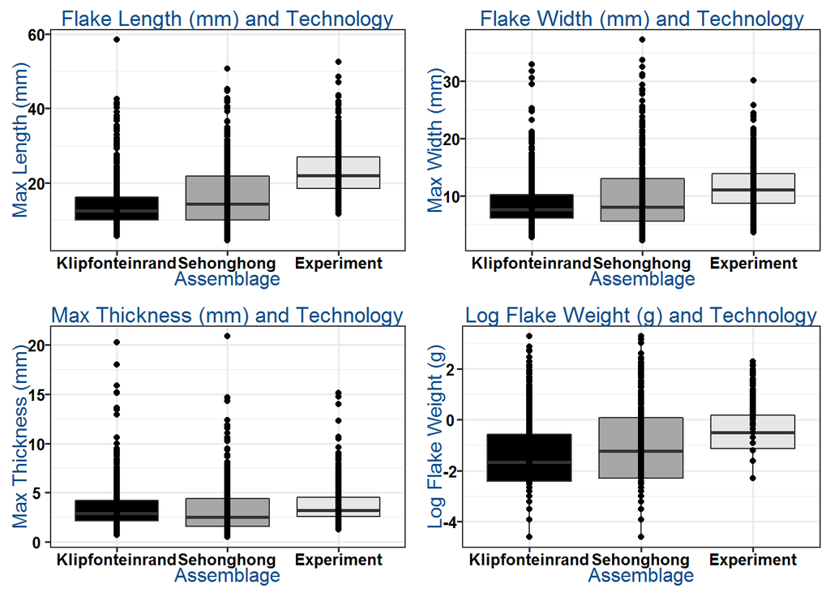

```r
lithic_data_flakes <-
  combined_arc_exp_data %>%
  filter(type == "flake")



#plot flake length by 'event', generate ANOVA test results and cohen's F effect size statistic
#Table 2

flake_plot_length <-
  fullTests_flakes(
    lithic_data_flakes,
    y_var = 'Max.length',
    y_label = "Max Length (mm)",
    graph_title = "Flake Length (mm) and Technology"
  )

flake_plot_width <-
  fullTests_flakes(
    lithic_data_flakes,
    y_var = 'Max.width',
    y_label = "Max Width (mm)",
    graph_title = "Flake Width (mm) and Technology"
  )

flake_plot_weight <-
  fullTests_flakes(
    lithic_data_flakes,
    y_var = 'log(Weight)',
    y_label = "Log Flake Weight (g)",
    graph_title = "Log Flake Weight (g) and Technology"
  )

flake_plot_thickness <-
  fullTests_flakes(
    lithic_data_flakes,
    y_var = 'Max.thick',
    y_label = "Max Thickness (mm)",
    graph_title = "Max Thickness (mm) and Technology"
  )

#Figure 8
source("http://peterhaschke.com/Code/multiplot.R") #multiplot source code

multiplot(
  flake_plot_length$plot,
  flake_plot_thickness$plot,
  flake_plot_width$plot,
  flake_plot_weight$plot,
  cols = 2
)
```

### Experimental data

Data preparation

```r
# Load total station data (update to latest file version)
experiment_data <-
  read_csv(paste0(here::here(), "/data/experiment_data.csv"),
           na = c("NA", "", '<NA>'))

# calculate lithic shape values, convert some to logs
experiment_logdata <-
  experiment_data %>%
  mutate(elongation = Max.width / Max.length,
         flatness = Max.thick / Max.width,
         form = flatness / elongation,
         volume = Max.length * Max.width * Max.thick) %>%
  mutate(volume = if_else(volume == 0, 0.01, volume)) %>%
  mutate_at(vars(Weight,
                 Max.length,
                 Max.width,
                 Max.thick,
                 elongation,
                 flatness,
                 form,
                 volume), log)
```

### Section 3.2.1 Lithic size and shape as predictors of lithic movement

Series 1-2 and 2-3 recording data: includes cores and flakes

Divide data into different recording series and recording series combinations for use in models

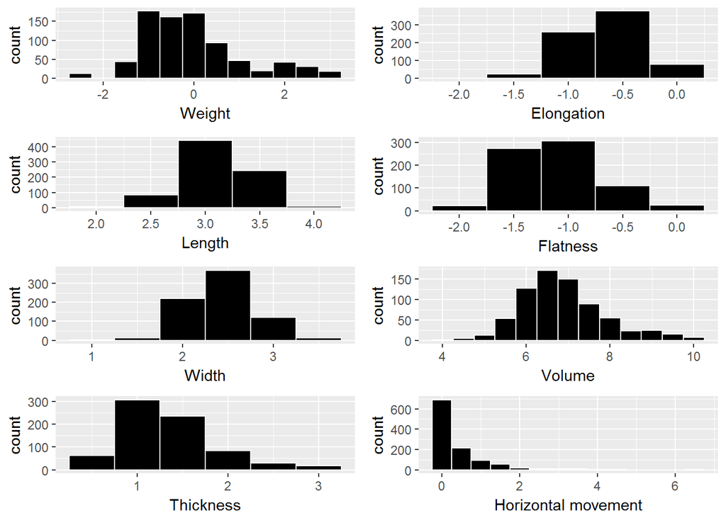

```r
series_2 <-
  experiment_logdata %>%
  filter(series == 2)

series_3 <-
  experiment_logdata %>%
  filter(series == 3)

series_2_3 <-
  experiment_logdata %>%
  filter(series %in% 2:3) %>%
  mutate_at(vars(class,
                 slope,
                 climate,
                 series),
            factor)

#subsets into bipolar (cb) and freehand (cf) cores
series_2_3_4 <-
  experiment_logdata %>%
  filter(series %in% 2:4) %>%
  mutate_at(vars(class,
                 slope,
                 climate,
                 series),
            factor) %>%
  filter(class %in% c("cb", "cf"))

#plot predictor variables to assess data distributions
#Figure 12

qplot_fn <- function(col, plot_xlabs){
  qplot(
    col,
    geom = "histogram",
    binwidth = 0.5,
    xlab = plot_xlabs,
    fill = I("black"),
    col = I("white")
  )
}


plot_xlabs <- c("Weight",
                "Length",
                "Width",
                "Thickness",
                "Elongation",
                "Flatness",
                "Volume",
                "Horizontal movement")

list_of_plots <-
  experiment_logdata %>%
  select(Weight,
         Max.length,
         Max.width,
         Max.thick,
         elongation,
         flatness,
         volume,
         near_dist_m) %>%
  map2(.,
       plot_xlabs,
       ~qplot_fn(.x, .y))

multiplot(plotlist = list_of_plots,
          cols = 2)
```

Check response variable (movement) against theoretical distributions for best fit

Figure S1

generate hypothetical distribution using movement dataset parameters

```r
control <- as.numeric(na.omit(experiment_data$near_dist_m))

## estimate the parameters as fit to weibull, exponential, log normal, and gamma distributions

dists <- c("weibull", "exp", "lnorm", "gamma")
fits <- map(dists, ~fitdist(control, .x))
plot_fns <- c(denscomp, cdfcomp, qqcomp, ppcomp)

#model diagnostics plot

# windows()
png_file <- paste0(here::here(), "/code/model_diagnostics_plot.png")
png(png_file, width = 500, height = 500, units = "px")
par(mfrow = c(2, 2))
plot.legend <- c("Weibull", "exp", "lognormal", "gamma")
plot_fns %>% invoke_map( , fits)
```

```r
dev.off()
```

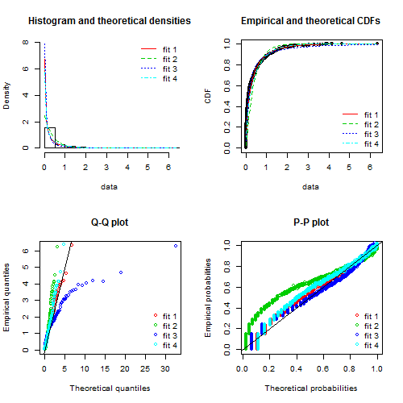

```r
knitr::include_graphics(png_file)
```

### Series 2 tool movement modeled against tool size

use generalize linear model framework model tool movement as Weibull distribution

Table 4

```r
series_2_size_gamlss1 = gamlss(
  near_dist_m ~ Weight + Max.length + Max.width + Max.thick,
  sigma.formula = ~ Weight + Max.length + Max.width + Max.thick,
  data = na.omit(series_2),
  family = WEI
)
```

```
## GAMLSS-RS iteration 1: Global Deviance = 42.1782
## GAMLSS-RS iteration 2: Global Deviance = 41.5946
## GAMLSS-RS iteration 3: Global Deviance = 41.5361
## GAMLSS-RS iteration 4: Global Deviance = 41.5292
## GAMLSS-RS iteration 5: Global Deviance = 41.5261
## GAMLSS-RS iteration 6: Global Deviance = 41.5255
```

```r
#model summary
#Table 4

summary(series_2_size_gamlss1)
```

```
## Family:  c("WEI", "Weibull")
##
## Call:  gamlss(formula = near_dist_m ~ Weight + Max.length +
##     Max.width + Max.thick, sigma.formula = ~Weight +
##     Max.length + Max.width + Max.thick, family = WEI,
##     data = na.omit(series_2))
##
## Fitting method: RS()
##
## ------------------------------------------------------------------
## Mu link function:  log
## Mu Coefficients:
##             Estimate Std. Error t value Pr(>|t|)
## (Intercept) -1.39242    2.02246  -0.688  0.49167
## Weight      -0.17337    0.27275  -0.636  0.52549
## Max.length  -0.01025    0.41670  -0.025  0.98040
## Max.width    0.67574    0.34736   1.945  0.05265 .
## Max.thick   -0.89944    0.31687  -2.839  0.00484 **
## ---
## Signif. codes:  0 '***' 0.001 '**' 0.01 '*' 0.05 '.' 0.1 ' ' 1
##
## ------------------------------------------------------------------
## Sigma link function:  log
## Sigma Coefficients:
##              Estimate Std. Error t value Pr(>|t|)
## (Intercept)  0.178530   1.351994   0.132    0.895
## Weight       0.006009   0.176743   0.034    0.973
## Max.length   0.024220   0.269269   0.090    0.928
## Max.width   -0.115814   0.250022  -0.463    0.644
## Max.thick   -0.053834   0.209034  -0.258    0.797
##
## ------------------------------------------------------------------
## No. of observations in the fit:  315
## Degrees of Freedom for the fit:  10
##       Residual Deg. of Freedom:  305
##                       at cycle:  6
##
## Global Deviance:     41.52546
##             AIC:     61.52546
##             SBC:     99.05118
```

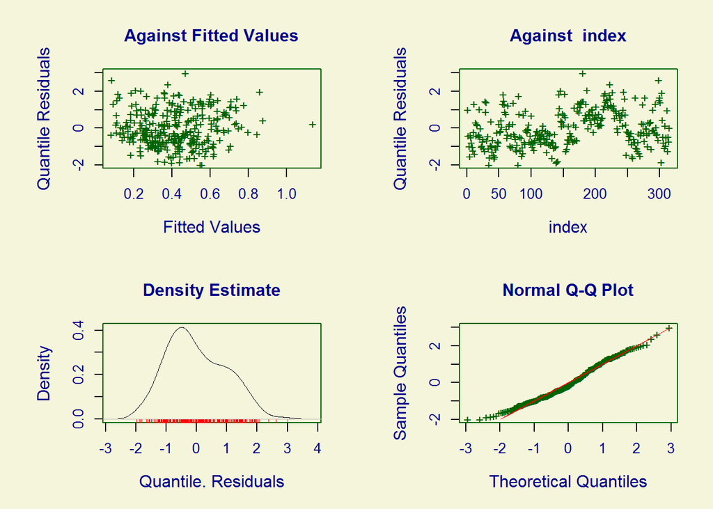

```
##        Summary of the Quantile Residuals
##                            mean   =  0.002727259
##                        variance   =  0.9515869
##                coef. of skewness  =  0.3566829
##                coef. of kurtosis  =  2.46592
## Filliben correlation coefficient  =  0.9900363
```

```r
#model diagnostic plot
#Figure S2

  par(
    mfrow = c(2, 2),
    mar = par("mar") + c(0, 1, 0, 0),
    col.axis = "blue4",
    col = "blue4",
    col.main = "blue4",
    col.lab = "blue4",
    pch = "+",
    cex = .45,
    cex.lab = 1.2,
    cex.axis = 1,
    cex.main = 1.2
  )

plot(series_2_size_gamlss1)
```

### Series 2 tool movement modeled against tool shape

use generalize linear model framework model tool movement as Weibull distribution

Table 4

```r
series_2_shape_gamlss1 = gamlss(
  near_dist_m ~ volume + elongation + flatness,
  sigma.formula = ~ volume + elongation + flatness,
  data = na.omit(series_2),
  family = WEI
)
```

```
## GAMLSS-RS iteration 1: Global Deviance = 42.9467
## GAMLSS-RS iteration 2: Global Deviance = 42.3699
## GAMLSS-RS iteration 3: Global Deviance = 42.3093
## GAMLSS-RS iteration 4: Global Deviance = 42.3022
## GAMLSS-RS iteration 5: Global Deviance = 42.2994
## GAMLSS-RS iteration 6: Global Deviance = 42.2989
```

model summary Table 4

```r
summary(series_2_shape_gamlss1)
```

```
## Family:  c("WEI", "Weibull")
##
## Call:  gamlss(formula = near_dist_m ~ volume + elongation +
##     flatness, sigma.formula = ~volume + elongation +
##     flatness, family = WEI, data = na.omit(series_2))
##
## Fitting method: RS()
##
## ------------------------------------------------------------------
## Mu link function:  log
## Mu Coefficients:
##             Estimate Std. Error t value Pr(>|t|)
## (Intercept) -0.21615    0.78526  -0.275  0.78330
## volume      -0.24236    0.08465  -2.863  0.00448 **
## elongation  -0.04594    0.25155  -0.183  0.85522
## flatness    -0.82658    0.20626  -4.007 7.71e-05 ***
## ---
## Signif. codes:  0 '***' 0.001 '**' 0.01 '*' 0.05 '.' 0.1 ' ' 1
##
## ------------------------------------------------------------------
## Sigma link function:  log
## Sigma Coefficients:
##              Estimate Std. Error t value Pr(>|t|)
## (Intercept)  0.137825   0.551019   0.250    0.803
## volume      -0.042420   0.057496  -0.738    0.461
## elongation  -0.072640   0.156516  -0.464    0.643
## flatness    -0.001746   0.148321  -0.012    0.991
##
## ------------------------------------------------------------------
## No. of observations in the fit:  315
## Degrees of Freedom for the fit:  8
##       Residual Deg. of Freedom:  307
##                       at cycle:  6
##
## Global Deviance:     42.29887
##             AIC:     58.29887
##             SBC:     88.31945
```

model diagnostic plot Figure S3

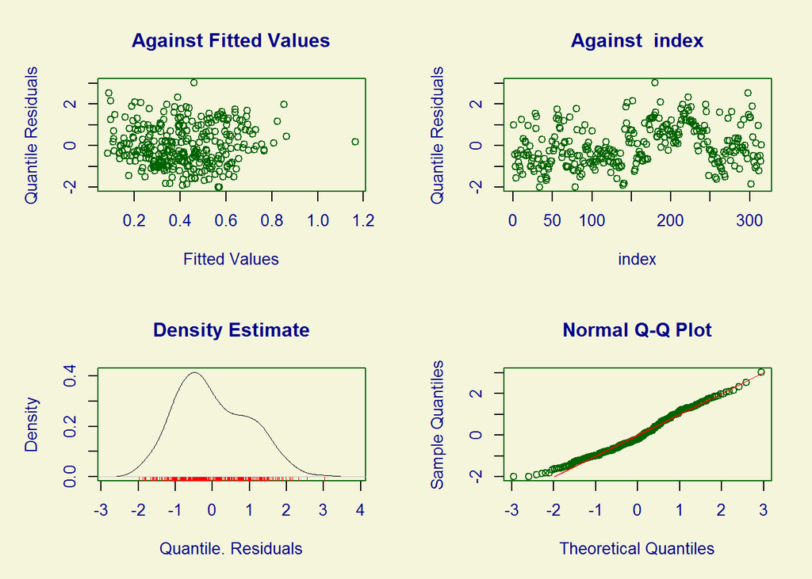

```
##        Summary of the Quantile Residuals
##                            mean   =  0.002864068
##                        variance   =  0.9506946
##                coef. of skewness  =  0.3622149
##                coef. of kurtosis  =  2.47575
## Filliben correlation coefficient  =  0.9899822
```

```r
plot(series_2_shape_gamlss1) #plot model diagnostics
```

Model comparisons using AIC criteria Table 6

```r
AIC(series_2_shape_gamlss1, series_2_size_gamlss1)
```

```
##                        df      AIC
## series_2_shape_gamlss1  8 58.29887
## series_2_size_gamlss1  10 61.52546
```

### Series 3 tool movement modeled against tool size

use generalize linear model framework model tool movement as Weibull distribution

Table 5

```r
series_3_size_gamlss1 = gamlss(
  near_dist_m ~ Weight + Max.length + Max.width + Max.thick,
  sigma.formula = ~ Weight + Max.length + Max.width + Max.thick,
  data = na.omit(series_3),
  family = WEI
)
```

```
## GAMLSS-RS iteration 1: Global Deviance = 175.5435
## GAMLSS-RS iteration 2: Global Deviance = 175.1824
## GAMLSS-RS iteration 3: Global Deviance = 175.1331
## GAMLSS-RS iteration 4: Global Deviance = 175.1129
## GAMLSS-RS iteration 5: Global Deviance = 175.109
## GAMLSS-RS iteration 6: Global Deviance = 175.1038
## GAMLSS-RS iteration 7: Global Deviance = 175.1015
## GAMLSS-RS iteration 8: Global Deviance = 175.1015
```

Model summary Table 5

```r
summary(series_3_size_gamlss1)
```

```
## Family:  c("WEI", "Weibull")
##
## Call:  gamlss(formula = near_dist_m ~ Weight + Max.length +
##     Max.width + Max.thick, sigma.formula = ~Weight +
##     Max.length + Max.width + Max.thick, family = WEI,
##     data = na.omit(series_3))
##
## Fitting method: RS()
##
## ------------------------------------------------------------------
## Mu link function:  log
## Mu Coefficients:
##             Estimate Std. Error t value Pr(>|t|)
## (Intercept)  -2.5879     2.4383  -1.061   0.2894
## Weight       -0.5411     0.3254  -1.663   0.0974 .
## Max.length    0.4356     0.4771   0.913   0.3620
## Max.width     0.4491     0.3486   1.288   0.1986
## Max.thick    -0.6080     0.3871  -1.571   0.1173
## ---
## Signif. codes:  0 '***' 0.001 '**' 0.01 '*' 0.05 '.' 0.1 ' ' 1
##
## ------------------------------------------------------------------
## Sigma link function:  log
## Sigma Coefficients:
##             Estimate Std. Error t value Pr(>|t|)
## (Intercept)  1.69869    1.71681   0.989    0.323
## Weight       0.19268    0.20179   0.955    0.340
## Max.length  -0.33088    0.34539  -0.958    0.339
## Max.width   -0.22754    0.25643  -0.887    0.376
## Max.thick   -0.06855    0.21586  -0.318    0.751
##
## ------------------------------------------------------------------
## No. of observations in the fit:  304
## Degrees of Freedom for the fit:  10
##       Residual Deg. of Freedom:  294
##                       at cycle:  8
##
## Global Deviance:     175.1015
##             AIC:     195.1015
##             SBC:     232.2717
```

Model diagnostic plot Figure S4

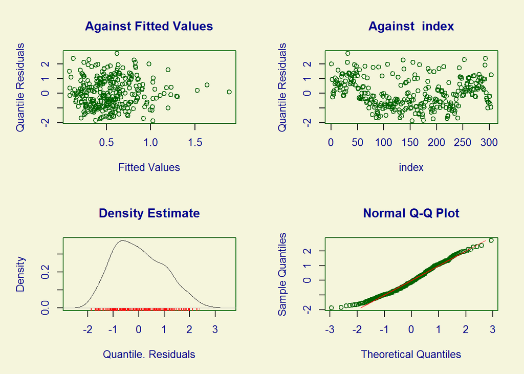

```
##        Summary of the Quantile Residuals
##                            mean   =  0.002260506
##                        variance   =  0.9541484
##                coef. of skewness  =  0.3452493
##                coef. of kurtosis  =  2.366232
## Filliben correlation coefficient  =  0.9898304
```

```r
plot(series_3_size_gamlss1)
```

use generalize linear model framework model tool movement as Weibull distribution

Table 5

```r
series_3_shape_gamlss1 = gamlss(
  near_dist_m ~ volume + elongation + flatness,
  sigma.formula = ~ volume + elongation + flatness,
  data = na.omit(series_3),
  family = WEI
)
```

```
## GAMLSS-RS iteration 1: Global Deviance = 190.5116
## GAMLSS-RS iteration 2: Global Deviance = 189.416
## GAMLSS-RS iteration 3: Global Deviance = 189.149
## GAMLSS-RS iteration 4: Global Deviance = 189.0657
## GAMLSS-RS iteration 5: Global Deviance = 189.038
## GAMLSS-RS iteration 6: Global Deviance = 189.0349
## GAMLSS-RS iteration 7: Global Deviance = 189.0305
## GAMLSS-RS iteration 8: Global Deviance = 189.0307
```

Model summary Table 5

```r
summary(series_3_shape_gamlss1)
```

```
## Family:  c("WEI", "Weibull")
##
## Call:  gamlss(formula = near_dist_m ~ volume + elongation +
##     flatness, sigma.formula = ~volume + elongation +
##     flatness, family = WEI, data = na.omit(series_3))
##
## Fitting method: RS()
##
## ------------------------------------------------------------------
## Mu link function:  log
## Mu Coefficients:
##             Estimate Std. Error t value Pr(>|t|)
## (Intercept)  1.17071    0.84381   1.387  0.16636
## volume      -0.41671    0.08681  -4.800 2.52e-06 ***
## elongation  -0.15230    0.25067  -0.608  0.54394
## flatness    -0.73635    0.23984  -3.070  0.00234 **
## ---
## Signif. codes:  0 '***' 0.001 '**' 0.01 '*' 0.05 '.' 0.1 ' ' 1
##
## ------------------------------------------------------------------
## Sigma link function:  log
## Sigma Coefficients:
##             Estimate Std. Error t value Pr(>|t|)
## (Intercept)  0.12506    0.61798   0.202    0.840
## volume      -0.05032    0.06854  -0.734    0.463
## elongation  -0.02573    0.17022  -0.151    0.880
## flatness    -0.11253    0.12679  -0.888    0.376
##
## ------------------------------------------------------------------
## No. of observations in the fit:  304
## Degrees of Freedom for the fit:  8
##       Residual Deg. of Freedom:  296
##                       at cycle:  8
##
## Global Deviance:     189.0307
##             AIC:     205.0307
##             SBC:     234.7669
```

Model diagnostic plot Figure S5

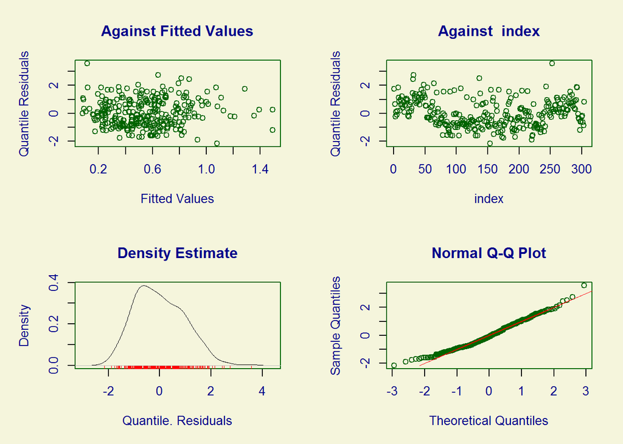

```
##        Summary of the Quantile Residuals
##                            mean   =  0.005478131
##                        variance   =  0.942691
##                coef. of skewness  =  0.4219325
##                coef. of kurtosis  =  2.835355
## Filliben correlation coefficient  =  0.9910903
```

```r
plot(series_3_shape_gamlss1)
```

Model comparisons using AIC criteria Table 6

```r
AIC(series_3_shape_gamlss1, series_3_size_gamlss1)
```

```
##                        df      AIC
## series_3_size_gamlss1  10 195.1015
## series_3_shape_gamlss1  8 205.0307
```

### Section 3.2.2. Lithic class, slope, and climate as predictors of lithic movement

Series 1-2 and 2-3 data cores and flakes

Function to plot comparisons of tool movement by class, slope, and climate

```r
createMovementPlot <-
  function(df,
           ylabel,
           graph_title,
           facet1,
           facet2) {
    ggplot(data = subset(df, !is.na(slope)),
                              aes(x = class,
                                  y = log(near_dist_m))) +
      geom_boxplot(outlier.size = 0,
                   outlier.colour = 'white') +
      geom_sina(alpha = 0.1,
                scale = FALSE,
                maxwidth = 0.2) +
      facet_grid(as.formula(paste(facet1, "~", facet2))) +
      theme_great_plot() +
      labs(title = graph_title) +
      ylab(ylabel) +
      scale_x_discrete(labels = c("Bipolar core", "Freehand core", "Flake"))
  }
```

Plot tool movement by series, class and slope Figure 10

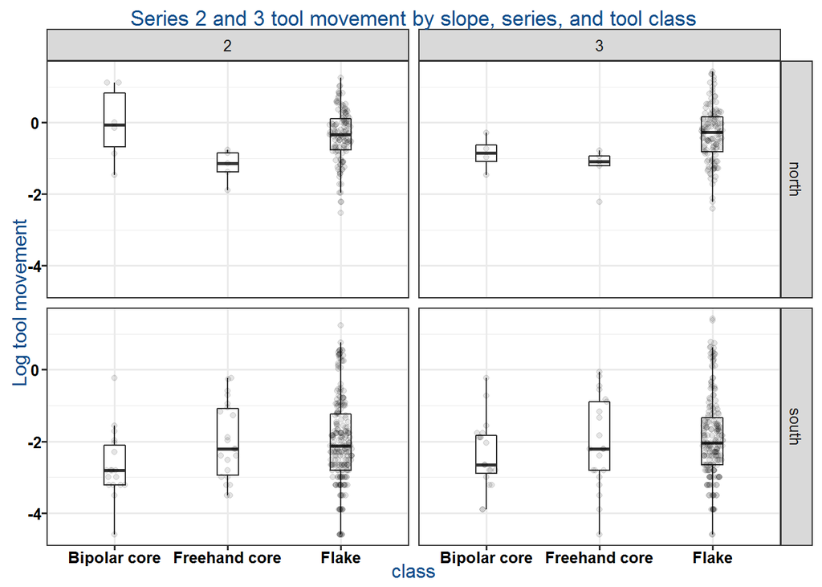

```r
createMovementPlot(
  series_2_3,
  "Log tool movement",
  "Series 2 and 3 tool movement by slope, series, and tool class",
  'slope',
  'series'
)
```

ANOVA model: tool movement, series, class, slope and their interactions Table 7

```r
model_10 <- with(series_2_3,
                 aov(
  log(near_dist_m) ~
    series +
    class +
    slope *  climate +
    class *  series +
    class *  slope +
    series * slope
))
```

model summary Table 7

```r
summary(model_10)
```

```
##                Df Sum Sq Mean Sq F value   Pr(>F)
## series          1    2.4     2.4   2.139   0.1441
## class           2   33.8    16.9  15.194 3.38e-07 ***
## slope           1  448.7   448.7 403.141  < 2e-16 ***
## slope:climate   1    0.5     0.5   0.434   0.5102
## series:class    2    0.3     0.2   0.149   0.8620
## class:slope     2    7.4     3.7   3.342   0.0359 *
## Residuals     768  854.8     1.1
## ---
## Signif. codes:  0 '***' 0.001 '**' 0.01 '*' 0.05 '.' 0.1 ' ' 1
## 7 observations deleted due to missingness
```

ANOVA effect size Table 7

```r
cohens_f(model_10)
```

```
##        series         class         slope slope:climate  series:class
##    0.05276850    0.19891588    0.72451587    0.02377455    0.01966586
##   class:slope
##    0.09328827
```

Series 1-2, 2-3, and 3-4 data cores ONLY

Plot tool movement by slope, series and tool class Figure 11

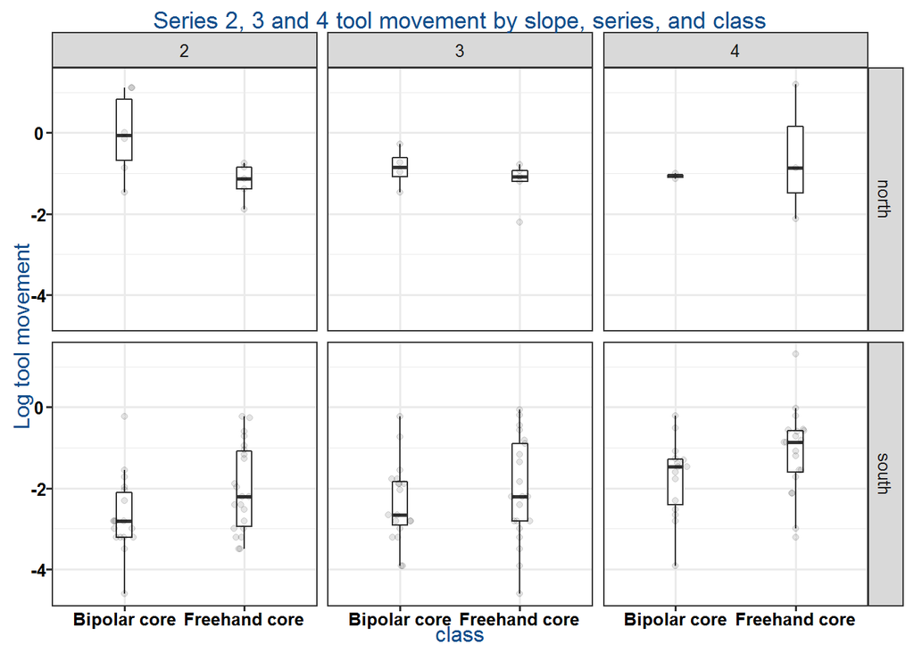

```r
createMovementPlot(
  series_2_3_4,
  "Log tool movement",
  "Series 2, 3 and 4 tool movement by slope, series, and class",
  'slope',
  'series'
)
```

ANOVA model: tool movement, climate, series, class and their interactions Table 8

```r
model_11 <-
  with(series_2_3_4,
       aov(log(near_dist_m)~climate+
                    series +
                    class +
                    series * slope +
                    series * class))
```

model summary Table 8

```r
summary(model_11)
```

```
##               Df Sum Sq Mean Sq F value   Pr(>F)
## climate        1   1.98    1.98   1.813  0.18053
## series         1  10.27   10.27   9.409  0.00262 **
## class          1   3.30    3.30   3.022  0.08448 .
## slope          1  33.13   33.13  30.341 1.85e-07 ***
## series:slope   2   4.35    2.17   1.991  0.14064
## series:class   2   1.17    0.58   0.535  0.58683
## Residuals    131 143.03    1.09
## ---
## Signif. codes:  0 '***' 0.001 '**' 0.01 '*' 0.05 '.' 0.1 ' ' 1
## 1 observation deleted due to missingness
```

ANOVA effect size Table 8

```r
cohens_f(model_11)
```

```
##      climate       series        class        slope series:slope
##   0.11762817   0.26800555   0.15188911   0.48125977   0.17435801
## series:class
##   0.09039354
```

### Section 3.2.3. Lithic orientation

subset data for analysis and plotting

```r
direction_data <-
  experiment_data %>%
  mutate(series = factor(series),
         class = factor(class))

direction_data_2 <-
  direction_data %>%
  filter(series == 2) %>%
  mutate(Identity = 1:nrow(.))

direction_data_3 <-
  direction_data %>%
  filter(series == 3) %>%
  mutate(Identity = 1:nrow(.))
```

Permutation tests for difference in means of tool orientation by series, slope, and class

Permutation test function

```r
create_perm_test <- function(df, y_var, x_var) {
  frm <- as.formula(sprintf("%s~%s", y_var, x_var))
  perm_test <- permKS(frm,
                      data = direction_data,
                      method = 'exact.mc',
                      control = permControl(nmc = 10 ^ 4))
  return(perm_test)
}
```

Permutation test results Table 9

```r
# list of permKS output to data frame, similar to what broom:tidy would give us
# but there's no method for permKS in broom, so we write our own
permKSlist2df <- function(lst){
  class(lst) <- "list"
  map_df(lst, ~bind_rows(unlist(.x)))
}

vars <- c("series", "slope", "class")

permKS_tests <- map(vars, ~create_perm_test(direction_data, "bearing_TN", .x))

permKS_tests_df <- permKSlist2df(permKS_tests)

permKS_tests_df
```

```
## # A tibble: 3 x 6
##   p.value           method               data.name p.conf.~ p.conf.~ nmc
##   <chr>             <chr>                <chr>     <chr>    <chr>    <chr>
## 1 0.76972302769723  K-Sample Exact Perm~ bearing_~ 0.75867~ 0.78046~ 10000
## 2 0.31036896310369  K-Sample Exact Perm~ bearing_~ 0.29842~ 0.32235~ 10000
## 3 0.268673132686731 K-Sample Exact Perm~ bearing_~ 0.25724~ 0.28017~ 10000
```

Series 2 orientation data by slope Subset series 2 and 3 north and south slope data

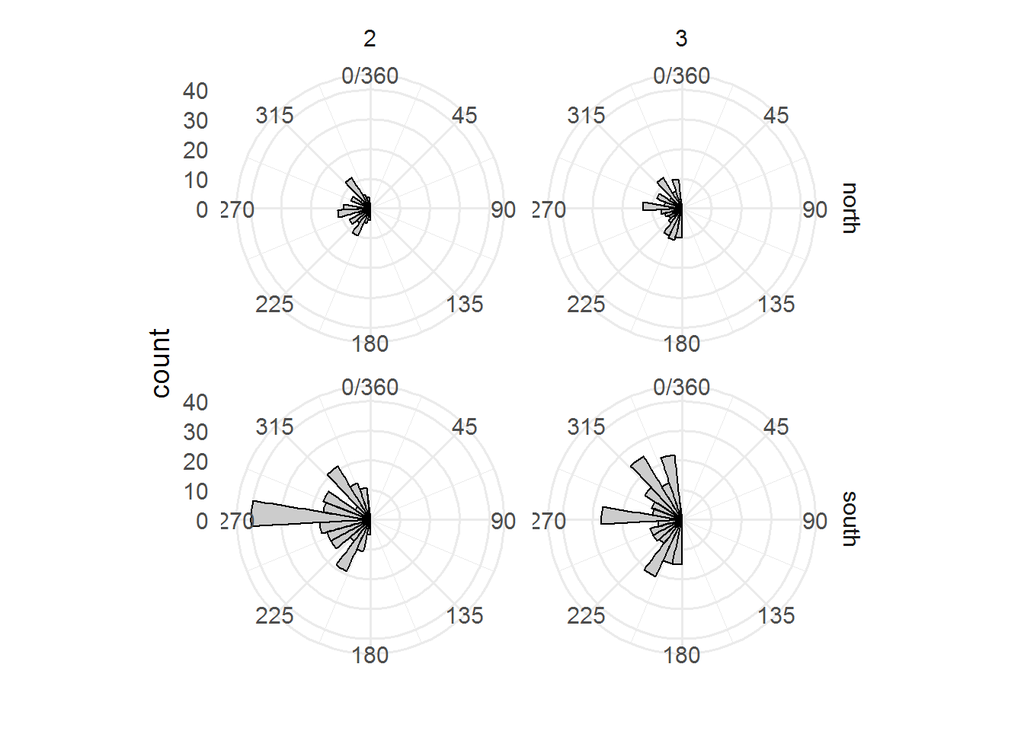

```r
direction_data %>%
  select(slope, series, bearing_TN ) %>%
  filter(!is.na(slope),
         series %in% 2:3) %>%
  ggplot() +
  geom_histogram(
    aes(x = bearing_TN),
    colour = "black",
    fill = "grey80") +
  theme(axis.text.x = element_text(size = 18)) +
  coord_polar(start = 0) +
  scale_x_continuous(limits = c(0, 360),
                     breaks = c(0, 45, 90, 135, 180, 225, 270, 315, 360)) +
  theme_minimal(base_size = 14) +
  xlab("") +
  theme(plot.title = element_text(hjust = 0.5)) +
  facet_grid(slope ~ series)
```

test tool orientation data against random No table #, data discussed in text

```
rayleigh.test(direction_data_2$bearing_TN)
rayleigh.test(direction_data_3$bearing_TN)
```

### Section 3.2.4. Lithic attrition

# Subset series 1, 2 and 3 data

```r
series_1_2_3 <-
  experiment_logdata %>%
  filter(series %in% 1:3) %>%
  mutate(class = factor(class))
```

Subset cores data (for series 1,2,3 and 4)

```r
series_cores <-
  experiment_logdata %>%
  filter(class %in% c("cb", "cf")) %>%
  mutate(class = factor(class))
```

Plot tool counts function

```r
tool_count_by_series_plot <- function(df) {
  ggplot(data = df,
         aes(x = Series,
             y = Number,
             fill = Class)) +
    geom_bar(stat = "identity",
             position = position_dodge(),
             color = "black") +
    theme_great_plot() +
    labs(title = "tool counts by series",
         x = "Series",
         y = "tool count") +
    #theme(plot.title = element_text(hjust = 0.5),text = element_text(size=20))+
    scale_x_discrete(labels = c("One", "Two", "Three", "Four")) +
    scale_fill_manual(
      values = c('black', 'grey', 'lightgray'),
      name = '',
      labels = c("Bipolar core", "Freehand core", "Flake")
    ) +
    geom_text(
      aes(label = Number),
      vjust = -0.3,
      color = "black",
      size = 3.5,
      position = position_dodge(0.9)
    )
}
```

### Series 1,2 and 3 core and flake attrition

```r
series_1_2_3_tally <-
series_1_2_3 %>%
  select(class, series) %>%
  group_by(class, series) %>%
  tally()

series_1_2_3_loss_tbl <-
  series_1_2_3_tally %>%
  spread(series, n) %>%
  as.data.frame() %>%
  remove_rownames() %>%
  column_to_rownames("class")
```

Chi-square on core and flake counts across recording series Table 10 effect size

```r
chi_sq_1_2_3 <- chisq.test(series_1_2_3_loss_tbl)
chies(chi_sq_1_2_3$statistic, sum(series_1_2_3_loss_tbl) - 1) #chi-square value and sample size
```

```
## Mean Differences ES:
##
##  d [ 95 %CI] = 0.05 [ -0.06 , 0.17 ]
##   var(d) = 0
##   p-value(d) = 0.35
##   U3(d) = 52.14 %
##   CLES(d) = 51.51 %
##   Cliff's Delta = 0.03
##
##  g [ 95 %CI] = 0.05 [ -0.06 , 0.17 ]
##   var(g) = 0
##   p-value(g) = 0.35
##   U3(g) = 52.14 %
##   CLES(g) = 51.51 %
##
##  Correlation ES:
##
##  r [ 95 %CI] = 0.03 [ -0.03 , 0.08 ]
##   var(r) = 0
##   p-value(r) = 0.35
##
##  z [ 95 %CI] = 0.03 [ -0.03 , 0.08 ]
##   var(z) = 0
##   p-value(z) = 0.35
##
##  Odds Ratio ES:
##
##  OR [ 95 %CI] = 1.1 [ 0.9 , 1.35 ]
##   p-value(OR) = 0.35
##
##  Log OR [ 95 %CI] = 0.1 [ -0.11 , 0.3 ]
##   var(lOR) = 0.01
##   p-value(Log OR) = 0.35
##
##  Other:
##
##  NNT = 65.07
##  Total N = 1193
```

Extract odds ratio and 95 % CI Table 11

```r
odd_1 <- oddsratio.wald(as.matrix(series_1_2_3_loss_tbl))
odd_1$measure
```

```
##                         NA
## odds ratio with 95% C.I. estimate     lower    upper
##                       cb 1.000000        NA       NA
##                       cf 1.206897 0.5719025 2.546936
##                       f  1.250000 0.7162777 2.181416
```

Figure 14

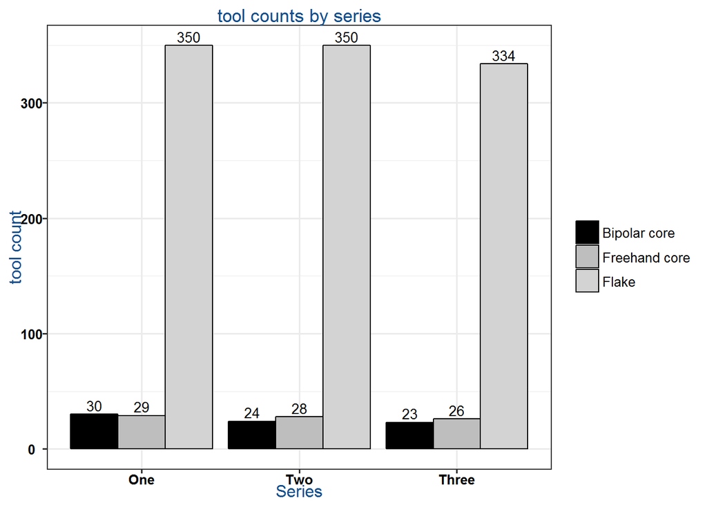

```r
series_1_2_3_tally %>%
  mutate(Series = factor(series)) %>%
  rename(Class = class,
         Number = n) %>%
  tool_count_by_series_plot()
```

Series 1,2,3 and 4 core attrition

```r
series_2_3_4_cores_tally <-
  series_cores %>%
  select(class, series) %>%
  group_by(class, series) %>%
  tally()

series_2_3_4_cores_loss_tbl <-
  series_2_3_4_cores_tally %>%
  spread(series, n) %>%
  as.data.frame() %>%
  remove_rownames() %>%
  column_to_rownames("class")
```

Chi-square on core counts across recording series Table 10 effect size

```r
chi_sq_2_3_4 <- chisq.test(series_2_3_4_cores_loss_tbl)
chies(chi_sq_2_3_4$statistic, sum(series_2_3_4_cores_loss_tbl) - 1) #chi-square value and sample size
```

```
## Mean Differences ES:
##
##  d [ 95 %CI] = 0.12 [ -0.16 , 0.4 ]
##   var(d) = 0.02
##   p-value(d) = 0.41
##   U3(d) = 54.69 %
##   CLES(d) = 53.32 %
##   Cliff's Delta = 0.07
##
##  g [ 95 %CI] = 0.12 [ -0.16 , 0.4 ]
##   var(g) = 0.02
##   p-value(g) = 0.41
##   U3(g) = 54.67 %
##   CLES(g) = 53.31 %
##
##  Correlation ES:
##
##  r [ 95 %CI] = 0.06 [ -0.08 , 0.2 ]
##   var(r) = 0.01
##   p-value(r) = 0.41
##
##  z [ 95 %CI] = 0.06 [ -0.08 , 0.2 ]
##   var(z) = 0.01
##   p-value(z) = 0.41
##
##  Odds Ratio ES:
##
##  OR [ 95 %CI] = 1.24 [ 0.74 , 2.06 ]
##   p-value(OR) = 0.41
##
##  Log OR [ 95 %CI] = 0.21 [ -0.3 , 0.72 ]
##   var(lOR) = 0.07
##   p-value(Log OR) = 0.41
##
##  Other:
##
##  NNT = 28.93
##  Total N = 199
```

Extract odds ratio and 95 % CI Table 11

```r
odd_2 <- oddsratio.wald(as.matrix(series_2_3_4_cores_loss_tbl))
odd_2$measure
```

```
##                         NA
## odds ratio with 95% C.I. estimate     lower    upper
##                       cb 1.000000        NA       NA
##                       cf 1.206897 0.5719025 2.546936
```

Figure 15

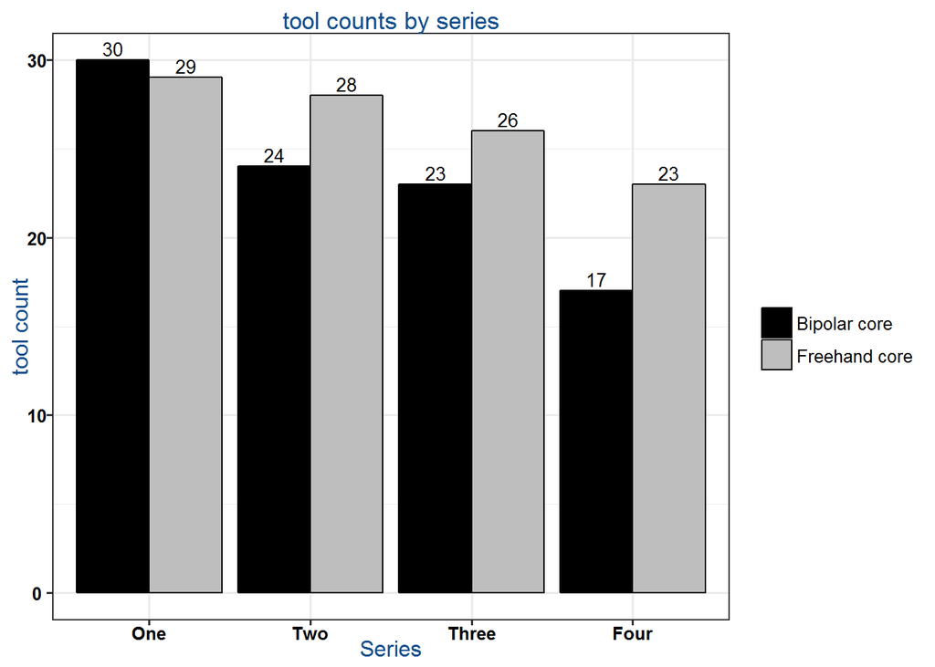

```r
series_2_3_4_cores_tally %>%
  mutate(Series = factor(series)) %>%
  rename(Class = class,
         Number = n) %>%
  tool_count_by_series_plot()
```

### Section 3.2.5. Simulating lithic movement and loss over longer time scales

Code set based off of work by Marwick and colleagues (2017), ‘Movement of lithics by trampling: An experiment in the Madjedbebe sediments, northern Australia’ doi.org/10.1016/j.jas.2017.01.008

```r
#Set the font size for the plots
base_size <- 8

#Load data

tool_event_coords_subset <- read_csv(paste0(here::here(), "/data/tool_three_event_movement.csv"))

#Combine distance recording measures for series 1 and 2

all_distances <-
  tool_event_coords_subset %>%
  select(near_dist_m.1,
         near_dist_m.2,
         near_dist_m.3)
```

### Simulation tool surface movement using “tool_three_event_movement.csv” dataset

```r
move_the_tool <- function(tool_num,
                              tool_event_coords_subset,
                              n){
      mydf <- tool_event_coords_subset

      # select tool
      df_tool <- mydf[mydf$Identity == tool_num, ]

      # starting location
      before_simulation <- dplyr::select(df_tool,
                                         near_dist_m.1)

      # movement differences that we can resample from
      series2 <- dplyr::select(df_tool,
                               near_dist_m.2)

      series3 <- dplyr::select(df_tool,
                               near_dist_m.3)

      # put differences into list to use easily
      # pool all tool distances, without respect to the
      # distances associated with this specific tool
      # and draw randomly from all distances for all tools
      diff_list <- as.list(all_distances)

      tool_coords_simulated <-
            vector("list", n)

      for(i in 1:n){

            # to index the previous event
            j <- i - 1

            # if this is the first move, start at 'before'
            # otherwise start at the previous location

            if(i == 1){
                  starting_location <- before_simulation
            }else{
                  starting_location <- tool_coords_simulated[[j]]
            }

            # get coords for new location of the tool after
            # this event by randomly sampling for the diffs
            # for the tool that we observed during the experiment
            if(i == 1){
                  # if this is the first move, use the starting point coords
                  tool_coords_simulated[[1]] <-  starting_location
            }else{

                  # get a random draw from the observed coords for this tool
                  random_draw <- diff_list[[sample(length(diff_list), 1)]]
                  # Model Version 2: randomly flip the sign of the movement value
                  # Un-hash the code line below to use it
                  # random_draw <- sample(c(random_draw, -random_draw), 1)

                  #print("unaltered random draw")
                  #print(random_draw[,3])


                  # apply random draw from observed coords to this tool
                  tool_coords_simulated[[i]] <-
                        starting_location + random_draw

                  #print(i)
            }

      }

      # make into data frame
      tool_coords_simulated_df <-
            do.call(rbind, tool_coords_simulated)

      tool_coords_simulated_df$tool_num <- tool_num
      tool_coords_simulated_df$event <- 1:nrow(tool_coords_simulated_df)

      names(tool_coords_simulated_df) <-
            c("Distance",
              "Identity",
              "Event")

      return(tool_coords_simulated_df)

}

move_the_tool(1, tool_event_coords_subset, 20)
```

```
## # A tibble: 20 x 3
##    Distance Identity Event
##       <dbl>    <dbl> <int>
##  1   0.0300     1.00     1
##  2   0.0600     1.00     2
##  3   1.03       1.00     3
##  4   2.00       1.00     4
##  5   2.97       1.00     5
##  6   3.16       1.00     6
##  7   4.13       1.00     7
##  8   5.10       1.00     8
##  9   5.29       1.00     9
## 10   5.32       1.00    10
## 11   5.35       1.00    11
## 12   6.32       1.00    12
## 13   7.29       1.00    13
## 14   7.32       1.00    14
## 15   7.35       1.00    15
## 16   8.32       1.00    16
## 17   9.29       1.00    17
## 18  10.3        1.00    18
## 19  10.5        1.00    19
## 20  11.4        1.00    20
```

```r
# functions to move ALL the tools n many times and create plot

move_all_the_tools <- function(n, tool_event_coords_subset){

      # for each tool, move it n times

      how_many_tools <- nrow(tool_event_coords_subset)

      # store the output
      all_the_tools <- vector("list", how_many_tools)

      for(i in 1:380){
            all_the_tools[[i]] <-
                  move_the_tool(tool_num = i,
                                    tool_event_coords_subset,
                                    n = n)
      }

      # make into data frame
      all_the_tools_df <-
            do.call(rbind, all_the_tools)

      return(all_the_tools_df)

}
run_simulation_plot<-function(n, tool_event_coords_subset){
      # n = how many times to move each tool
      moved <-
            move_all_the_tools(n = n,
                                   tool_event_coords_subset)

      # Get the axis limits of the plot
      # range of hor movement
      rnge_n <- max(moved$Distance, na.rm = TRUE) - min(moved$Distance, na.rm = TRUE)
      rngs <- rnge_n
      max_extent <- round(rngs[which.max(rngs)], 3)

      # hor xmin, ymin, etc.
      const <- 1.2
      xmin <- median(moved$Distance, na.rm = TRUE) - max_extent/const
      xmax <- median(moved$Distance, na.rm = TRUE) + max_extent/const

      # movement over time
      # distribution of hordist at event n
      moved_n <- moved[moved$Event == n,]
      moved_n$hdist <-
            sqrt(
                  (tool_event_coords_subset$near_dist_m.1 - moved_n$Distance)^2
            )

      #How many tools beyond 5 m boundary?
      print(paste("Number beyond 5m boundary:",
                  length(which(moved_n$hdist > 5))))

      # distribution of horizontal distance of all lithics at position of last event

      moved_plot <-
            ggplot(moved_n,
                   aes(hdist)) +
            geom_histogram(bins = 20) +
            labs(title = glue('Horizontal distance from starting point after {prettyNum(n, big.mark = ",")} events'), x = "Distance (m)", y = "Count") +
            theme_great_plot(base_size) +
            geom_vline(xintercept=5, color = 'red')
}
```

```r
# I set eval = FALSE to save time when knitting this repeatedly while working on other sections.
sim_10 = run_simulation_plot(10, tool_event_coords_subset)
sim_100 = run_simulation_plot(100, tool_event_coords_subset)
sim_1000 = run_simulation_plot(1000, tool_event_coords_subset)
sim_10000 = run_simulation_plot(10000, tool_event_coords_subset)

grid.arrange(sim_10,
             sim_100,
             sim_1000,
             sim_10000,
             ncol = 2)
```

```
##  setting  value
##  version  R version 3.4.3 (2017-11-30)
##  system   x86_64, mingw32
##  ui       RTerm
##  language (EN)
##  collate  English_Australia.1252
##  tz       America/Los_Angeles
##  date     2018-01-25
##
##  package      * version    date       source
##  assertthat     0.2.0      2017-04-11 CRAN (R 3.4.0)
##  backports      1.1.2      2017-12-13 CRAN (R 3.4.3)
##  base         * 3.4.3      2017-12-06 local
##  bayesplot      1.4.0      2017-09-12 CRAN (R 3.4.3)
##  bindr          0.1        2016-11-13 CRAN (R 3.4.0)
##  bindrcpp     * 0.2        2017-06-17 CRAN (R 3.4.0)
##  boot           1.3-20     2017-07-30 CRAN (R 3.4.1)
##  broom          0.4.3      2017-11-20 CRAN (R 3.4.3)
##  cellranger     1.1.0.9000 2017-05-31 Github (rsheets/cellranger@024d5ba)
##  circular     * 0.4-93     2017-06-29 CRAN (R 3.4.1)
##  cli            1.0.0      2017-11-05 CRAN (R 3.4.2)
##  coda           0.19-1     2016-12-08 CRAN (R 3.4.0)
##  codetools      0.2-15     2016-10-05 CRAN (R 3.4.0)
##  coin           1.2-2      2017-11-28 CRAN (R 3.4.3)
##  colorspace     1.3-2      2016-12-14 CRAN (R 3.4.0)
##  compiler       3.4.3      2017-12-06 local
##  compute.es   * 0.2-4      2014-09-16 CRAN (R 3.4.1)
##  crayon         1.3.4      2017-09-26 Github (gaborcsardi/crayon@b5221ab)
##  data.table   * 1.10.4-3   2017-10-27 CRAN (R 3.4.2)
##  datasets     * 3.4.3      2017-12-06 local
##  devtools       1.13.4     2017-11-09 CRAN (R 3.4.2)
##  digest         0.6.14     2018-01-14 CRAN (R 3.4.3)
##  dplyr        * 0.7.4      2017-09-28 CRAN (R 3.4.2)
##  emmeans        1.1        2018-01-10 CRAN (R 3.4.3)
##  epitools     * 0.5-10     2017-10-26 CRAN (R 3.4.2)
##  estimability   1.2        2016-11-19 CRAN (R 3.4.1)
##  evaluate       0.10.1     2017-06-24 CRAN (R 3.4.0)
##  fitdistrplus * 1.0-9      2017-03-24 CRAN (R 3.4.3)
##  forcats      * 0.2.0      2017-01-23 CRAN (R 3.4.0)
##  foreign        0.8-69     2017-06-21 CRAN (R 3.4.0)
```

[output cut: 73 more lines]

```
##  tidyr        * 0.7.2      2017-10-16 CRAN (R 3.4.2)
##  tidyselect     0.2.3      2017-11-06 CRAN (R 3.4.2)
##  tidyverse    * 1.2.1      2017-11-14 CRAN (R 3.4.3)
##  TMB            1.7.12     2017-12-11 CRAN (R 3.4.3)
##  tools          3.4.3      2017-12-06 local
##  tweenr         0.1.5      2016-10-10 CRAN (R 3.4.0)
##  udunits2       0.13       2016-11-17 CRAN (R 3.4.0)
##  units          0.4-6      2017-08-27 CRAN (R 3.4.1)
##  utf8           1.1.2      2017-12-14 CRAN (R 3.4.3)
##  utils        * 3.4.3      2017-12-06 local
##  withr          2.1.1.9000 2018-01-08 Github (jimhester/withr@df18523)
##  xml2           1.1.1      2017-01-24 CRAN (R 3.4.1)
##  xtable         1.8-2      2016-02-05 CRAN (R 3.4.0)
##  yaml           2.1.16     2017-12-12 CRAN (R 3.4.3)
##  zoo            1.8-0      2017-04-12 CRAN (R 3.4.0)
```